# March Madness Win Probability & Bet Sizing

Ali Lalani, Steve Elengical, Weihao Huang

Spring 2026

# 1 Project Overview

This project develops a statistical framework for estimating NCAA March Madness game win probabilities and translating those probabilities into risk-aware betting decisions.

The workflow is:

1. Pair historical tournament teams into game-level observations.
2. Convert team statistics into matchup differences (Team A minus Team B).
3. Separate historical data into chronological training and test sets.
4. Use LASSO logistic regression for feature selection.
5. Evaluate the selected feature set with multivariate analysis.
6. Fit an interpretable logistic regression model.
7. Evaluate out-of-sample predictive performance.
8. Generate probabilities for supplied 2026 matchups.
9. Use the Kelly Criterion when sportsbook odds are available.

> **Important:** Sportsbook odds are not included in the current project folder. The betting section therefore provides a reproducible Kelly Criterion implementation but does not claim validated real-world betting returns without an odds dataset.

# 2 1. Setup

```r
library(dplyr)
library(stringr)
library(glmnet)
library(corrplot)
library(MVN)

# Locate the folder containing this R Markdown file
set.seed(6359)
```

Expected repository structure:

```
data/
  KenPom_Barttorvik.csv
  Tournament_Matchups.csv
```

# 3 2. Load Data

```r
kenpom <- read.csv(
  "/Users/alimuhammadlalani/Desktop/MSDS Spring 2026/MATH6359/Optimal Betting Size Project/data/KenPom_Barttorvik.csv",
  check.names = TRUE
)

matchups_raw <- read.csv(
  "/Users/alimuhammadlalani/Desktop/MSDS Spring 2026/MATH6359/Optimal Betting Size Project/data/Tournament_Matchups.csv",
  check.names = TRUE
)

dim(kenpom)
```

```
## [1] 1215  103
```

```r
dim(matchups_raw)
```

```
## [1] 2288    8
```

`make.names()`-compatible column names are used so variables containing spaces and `%` symbols can be referenced safely in R.

```r
head(kenpom)
```

```
##   YEAR CONF CONF.ID QUAD.NO QUAD.ID TEAM.NO TEAM.ID        TEAM SEED ROUND
## 1 2026  MAC      17      69       1    1215       2       Akron   12     0
## 2 2026  SEC      28      69       1    1214       3     Alabama    4     0
## 3 2026  B12       7      70       2    1213       8     Arizona    1     0
## 4 2026  SEC      28      70       2    1212      10    Arkansas    4     0
## 5 2026  B12       7      70       2    1211      25         BYU    6     0
## 6 2026  WAC      32      72       4    1210     253 Cal Baptist   13     0
##   K.TEMPO K.TEMPO.RANK  KADJ.T KADJ.T.RANK   K.OFF KO.RANK  KADJ.O KADJ.O.RANK
## 1 71.2230           44 70.2733          32 121.920       6 118.820          54
## 2 74.6151            5 73.0870           4 121.979       5 129.004           3
## 3 71.3814           37 69.7911          54 120.103      16 127.676           5
## 4 72.4168           19 70.9979          20 122.567       3 127.658           6
## 5 70.4428           78 69.9244          46 118.624      30 125.460          10
## 6 67.4426          223 65.8019         265 106.986     208 107.926         191
##      K.DEF KD.RANK   KADJ.D KADJ.D.RANK  KADJ.EM KADJ.EM.RANK BADJ.EM  BADJ.O
```

[output cut: 76 more lines]

```r
head(matchups_raw)
```

```
##   YEAR BY.YEAR.NO TEAM.NO          TEAM SEED ROUND CURRENT.ROUND SCORE
## 1 2026       2288    1207          Duke    1     1            64    NA
## 2 2026       2287    1168         Siena   16    64            64    NA
## 3 2026       2286    1176      Ohio St.    8     1            64    NA
## 4 2026       2285    1164           TCU    9    64            64    NA
## 5 2026       2284    1165    St. John's    5     1            64    NA
## 6 2026       2283    1177 Northern Iowa   12    64            64    NA
```

# 4 3. Construct Matchup-Level Data

The tournament matchup file stores each game as two consecutive team rows. We first verify that the file contains an even number of rows, assign a game identifier, and convert each pair into a single matchup.

```r
if (nrow(matchups_raw) %% 2 != 0) {
  stop("Tournament matchup data must contain an even number of rows.")
}

paired_raw <- matchups_raw %>%
  mutate(
    SourceRow = row_number(),
    GameID = ceiling(row_number() / 2)
  )

team_A <- paired_raw %>%
  group_by(GameID) %>%
  slice(1) %>%
  ungroup() %>%
  transmute(
    GameID,
    YEAR,
    CURRENT_ROUND = CURRENT.ROUND,
    Team_A = TEAM,
    Seed_A = SEED,
    Score_A = SCORE
  )

team_B <- paired_raw %>%
  group_by(GameID) %>%
  slice(2) %>%
  ungroup() %>%
  transmute(
    GameID,
    YEAR_B = YEAR,
    CURRENT_ROUND_B = CURRENT.ROUND,
    Team_B = TEAM,
    Seed_B = SEED,
    Score_B = SCORE
  )

games <- team_A %>%
  inner_join(team_B, by = "GameID")

# Verify that each consecutive row pair represents the same season and round.
stopifnot(all(games$YEAR == games$YEAR_B))
stopifnot(all(games$CURRENT_ROUND == games$CURRENT_ROUND_B))

games <- games %>%
  mutate(
    Team_A_Win = case_when(
      !is.na(Score_A) & !is.na(Score_B) & Score_A > Score_B ~ 1,
      !is.na(Score_A) & !is.na(Score_B) & Score_A < Score_B ~ 0,
      TRUE ~ NA_real_
    )
  ) %>%
  select(
    GameID, YEAR, CURRENT_ROUND,
    Team_A, Team_B, Seed_A, Seed_B,
    Score_A, Score_B, Team_A_Win
  )

table(games$YEAR, useNA = "ifany")
```

```
##
## 2008 2009 2010 2011 2012 2013 2014 2015 2016 2017 2018 2019 2021 2022 2023 2024
##   63   63   63   63   63   63   63   63   63   63   63   63   62   63   63   63
## 2025 2026
##   63   74
```

## 4.1 Prevent Team-Order Bias

If one side of the raw data is systematically listed first, the model could learn row ordering instead of basketball strength. Historical games are therefore randomly swapped for approximately half of the observations.

The 2026 unlabeled matchups are left in their original orientation so their reported probabilities correspond directly to the supplied Team A / Team B ordering.

```r
historical_games <- games %>%
  filter(!is.na(Team_A_Win))

future_games <- games %>%
  filter(is.na(Team_A_Win))

swap_idx <- sample(
  seq_len(nrow(historical_games)),
  size = floor(nrow(historical_games) / 2)
)

historical_randomized <- historical_games

historical_randomized$Team_A[swap_idx] <- historical_games$Team_B[swap_idx]
historical_randomized$Team_B[swap_idx] <- historical_games$Team_A[swap_idx]

historical_randomized$Seed_A[swap_idx] <- historical_games$Seed_B[swap_idx]
historical_randomized$Seed_B[swap_idx] <- historical_games$Seed_A[swap_idx]

historical_randomized$Score_A[swap_idx] <- historical_games$Score_B[swap_idx]
historical_randomized$Score_B[swap_idx] <- historical_games$Score_A[swap_idx]

historical_randomized$Team_A_Win[swap_idx] <-
  1 - historical_games$Team_A_Win[swap_idx]

all_games <- bind_rows(
  historical_randomized,
  future_games
) %>%
  arrange(desc(YEAR), GameID)

mean(historical_randomized$Team_A_Win)
```

```
## [1] 0.5317757
```

The historical target should now be approximately balanced between Team A wins and losses.

# 5 4. Join Team Statistics

KenPom/BartTorvik statistics are joined once for Team A and once for Team B using season and team name.

```r
matchups_with_stats <- all_games %>%
  left_join(
    kenpom,
    by = c("YEAR" = "YEAR", "Team_A" = "TEAM")
  ) %>%
  left_join(
    kenpom,
    by = c("YEAR" = "YEAR", "Team_B" = "TEAM"),
    suffix = c("_A", "_B")
  )
```

# 6 5. Matchup Feature Engineering

For each numeric statistic available for both teams, we calculate:

$$\text{Difference} = \text{Team A statistic} - \text{Team B statistic}$$

Positive values therefore indicate that Team A has a larger value for that metric.

```r
# Only generate differences from variables that originate in the
# KenPom/BartTorvik table. This prevents matchup fields such as final
# game scores from accidentally becoming predictors.
stat_names <- names(kenpom) %>%
  setdiff(c("YEAR", "TEAM"))

model_data <- matchups_with_stats

for (stat in stat_names) {
  col_a <- paste0(stat, "_A")
  col_b <- paste0(stat, "_B")
  diff_name <- paste0("Diff_", stat)

  if (
    col_a %in% names(model_data) &&
    col_b %in% names(model_data) &&
    is.numeric(model_data[[col_a]]) &&
    is.numeric(model_data[[col_b]])
  ) {
    model_data[[diff_name]] <- model_data[[col_a]] - model_data[[col_b]]
  }
}
```

## 6.1 Remove Leakage and Identifier Variables

Variables that encode tournament advancement, final win/loss totals, ranks, identifiers, or other post-outcome information are not used as predictors.

```r
model_data <- model_data %>%
  select(
    GameID,
    YEAR,
    CURRENT_ROUND,
    Team_A,
    Team_B,
    Team_A_Win,
    starts_with("Diff_")
  ) %>%
  select(
    -any_of(c(
      "Diff_ROUND",
      "Diff_GAMES",
      "Diff_W",
      "Diff_L",
      "Diff_WIN.",
      "Diff_QUAD.NO",
      "Diff_QUAD.ID",
      "Diff_TEAM.NO",
      "Diff_TEAM.ID"
    )),
    -contains(".RANK"),
    -contains("CONF")
  )

historical_model_data <- model_data %>%
  filter(!is.na(Team_A_Win)) %>%
  tidyr::drop_na()

prediction_2026 <- model_data %>%
  filter(YEAR == 2026) %>%
  filter(if_all(starts_with("Diff_"), ~ !is.na(.)))

dim(historical_model_data)
```

```
## [1] 1061   52
```

```r
dim(prediction_2026)
```

```
## [1] 74 52
```

# 7 6. Chronological Train/Test Split

A random game-level split can allow later seasons to influence a model that is evaluated on earlier seasons. To better approximate prospective prediction, this version uses a chronological holdout.

- **Training:** 2008–2022
- **Testing:** 2023–2025
- **Prediction:** supplied 2026 matchup rows

```r
training <- historical_model_data %>%
  filter(YEAR <= 2022)

testing <- historical_model_data %>%
  filter(YEAR >= 2023, YEAR <= 2025)

c(
  training_games = nrow(training),
  testing_games = nrow(testing)
)
```

```
## training_games  testing_games
##            876            185
```

# 8 7. Exploratory Correlation Analysis

The original dataset contains many strongly related basketball metrics. We examine correlations using the training data only.

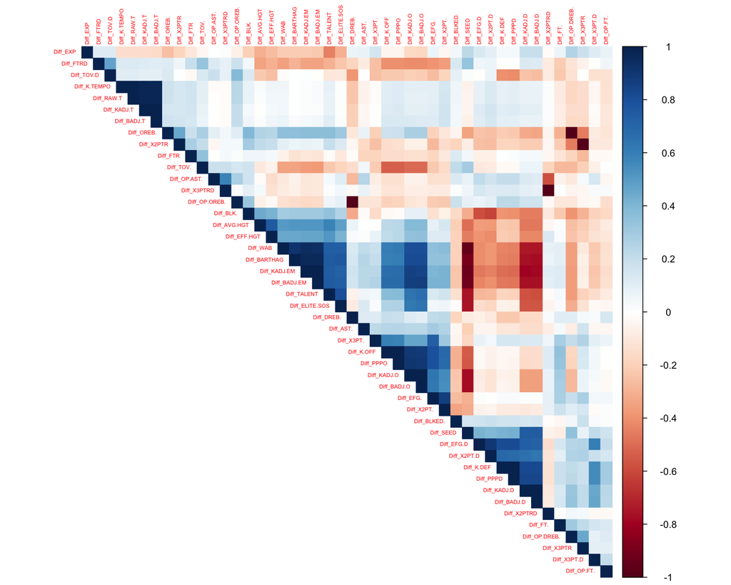

```r
train_predictors <- training %>%
  select(starts_with("Diff_"))

cor_matrix <- cor(
  train_predictors,
  use = "pairwise.complete.obs"
)

corrplot(
  cor_matrix,
  method = "color",
  type = "upper",
  order = "hclust",
  tl.cex = 0.45
)
```

Count unique pairs with absolute correlation greater than 0.70:

```r
cor_indices <- which(
  abs(cor_matrix) > 0.70 & upper.tri(cor_matrix),
  arr.ind = TRUE
)

strong_correlations <- data.frame(
  Variable_1 = rownames(cor_matrix)[cor_indices[, 1]],
  Variable_2 = colnames(cor_matrix)[cor_indices[, 2]],
  Correlation = cor_matrix[cor_indices]
) %>%
  arrange(desc(abs(Correlation)))

nrow(strong_correlations)
```

```
## [1] 73
```

```r
head(strong_correlations, 20)
```

```
##      Variable_1    Variable_2 Correlation
## 1    Diff_DREB. Diff_OP.OREB.  -1.0000000
## 2    Diff_OREB. Diff_OP.DREB.  -1.0000000
## 3    Diff_X2PTR    Diff_X3PTR  -1.0000000
## 4   Diff_X2PTRD   Diff_X3PTRD  -1.0000000
## 5  Diff_K.TEMPO    Diff_RAW.T   0.9992320
## 6    Diff_K.OFF     Diff_PPPO   0.9984239
## 7    Diff_K.DEF     Diff_PPPD   0.9978524
## 8   Diff_KADJ.T   Diff_BADJ.T   0.9952870
## 9   Diff_KADJ.O   Diff_BADJ.O   0.9934526
## 10 Diff_KADJ.EM  Diff_BADJ.EM   0.9912064
## 11  Diff_KADJ.D   Diff_BADJ.D   0.9903940
## 12   Diff_RAW.T   Diff_BADJ.T   0.9763079
## 13 Diff_K.TEMPO   Diff_BADJ.T   0.9748269
## 14  Diff_KADJ.T    Diff_RAW.T   0.9744766
## 15 Diff_K.TEMPO   Diff_KADJ.T   0.9740589
## 16 Diff_BADJ.EM  Diff_BARTHAG   0.9683748
## 17 Diff_KADJ.EM  Diff_BARTHAG   0.9620497
## 18 Diff_KADJ.EM      Diff_WAB   0.9427444
## 19    Diff_SEED      Diff_WAB  -0.9406559
## 20 Diff_BADJ.EM      Diff_WAB   0.9388130
```

# 9 8. LASSO Feature Selection

Feature selection is performed **only on the training data**. This prevents the test seasons from influencing which predictors are chosen.

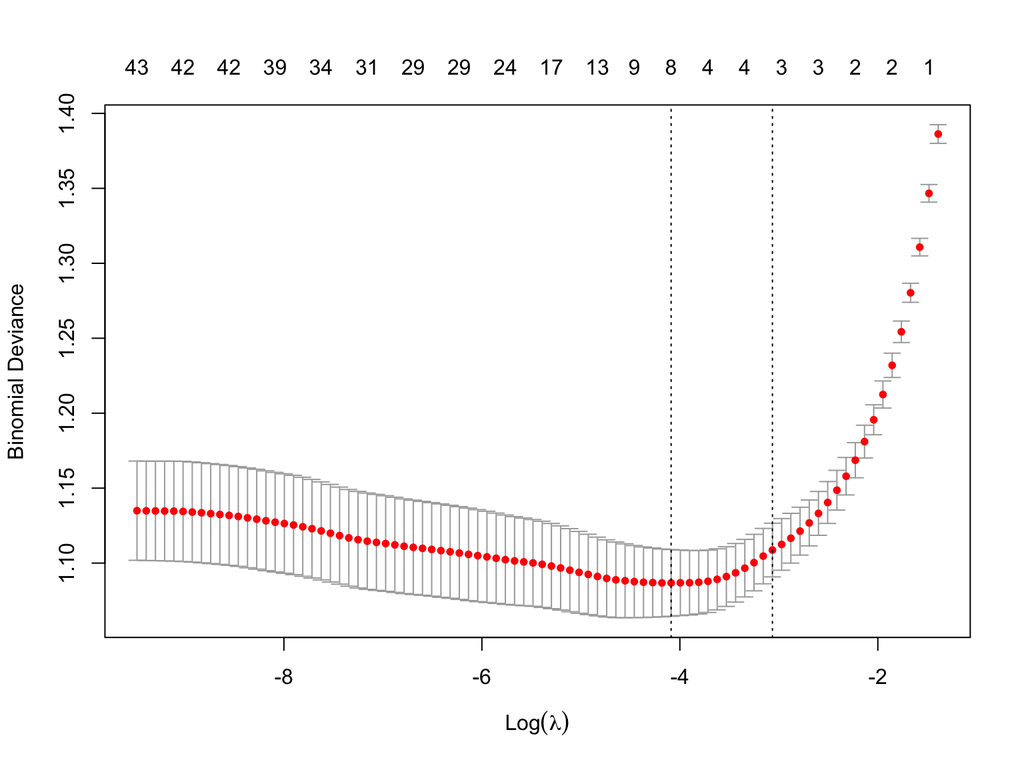

```r
x_train <- as.matrix(
  training %>%
    select(starts_with("Diff_"))
)

y_train <- training$Team_A_Win

set.seed(6359)

lasso_cv <- cv.glmnet(
  x = x_train,
  y = y_train,
  family = "binomial",
  alpha = 1,
  nfolds = 10
)

plot(lasso_cv)
```

```r
lasso_coef <- coef(lasso_cv, s = "lambda.min")

selected_features <- rownames(lasso_coef)[
  as.vector(lasso_coef != 0)
]

selected_features <- setdiff(
  selected_features,
  "(Intercept)"
)

selected_features
```

```
## [1] "Diff_BADJ.EM"  "Diff_FTR"      "Diff_TOV.D"    "Diff_OREB."
## [5] "Diff_OP.DREB." "Diff_AST."     "Diff_TALENT"   "Diff_WAB"
```

For transparency, display the non-zero LASSO coefficients:

```r
selected_coefs <- data.frame(
  Feature = rownames(lasso_coef),
  Coefficient = as.numeric(lasso_coef)
) %>%
  filter(Feature != "(Intercept)", Coefficient != 0) %>%
  arrange(desc(abs(Coefficient)))

selected_coefs
```

```
##         Feature   Coefficient
## 1  Diff_BADJ.EM  5.793027e-02
## 2      Diff_WAB  5.079396e-02
## 3    Diff_TOV.D  4.913680e-02
## 4   Diff_TALENT  4.545065e-03
## 5      Diff_FTR -3.848718e-03
## 6     Diff_AST. -1.130462e-03
## 7    Diff_OREB.  4.332733e-04
## 8 Diff_OP.DREB. -1.292002e-17
```

> The cleaned workflow intentionally re-runs LASSO after the chronological split. Therefore, the selected features may differ somewhat from the seven predictors reported in the original class report. The GitHub results should reflect this leakage-free rerun rather than hard-coding the earlier feature list.

# 10 9. Multivariate Analysis of Selected Features

The selected features can be examined jointly to assess whether their multivariate profiles differ between winning and losing teams.

## 10.1 Multivariate Normality

```r
selected_training <- training %>%
  select(all_of(selected_features))

mvn_result <- mvn(
  data = selected_training
)

mvn_result
```

```
## $multivariateNormality
##            Test   HZ p value MVN
## 1 Henze-Zirkler 3504       0  NO
##
## $univariateNormality
##               Test      Variable Statistic   p value Normality
## 1 Anderson-Darling Diff_BADJ.EM     2.2258  <0.001      NO
## 2 Anderson-Darling   Diff_FTR       0.5881   0.125      YES
## 3 Anderson-Darling  Diff_TOV.D      0.8544   0.028      NO
## 4 Anderson-Darling  Diff_OREB.      0.2354  0.7903      YES
## 5 Anderson-Darling Diff_OP.DREB.    0.2354  0.7903      YES
## 6 Anderson-Darling   Diff_AST.      0.4162  0.3314      YES
## 7 Anderson-Darling  Diff_TALENT     2.5389  <0.001      NO
## 8 Anderson-Darling   Diff_WAB       1.3982  0.0013      NO
##
## $Descriptives
##                 n        Mean   Std.Dev  Median     Min    Max    25th   75th
## Diff_BADJ.EM  876  0.38470320 13.495806  0.3000 -38.100 44.800  -7.825  8.025
## Diff_FTR      876 -0.43778539  6.298050 -0.7000 -23.300 19.500  -4.500  3.700
## Diff_TOV.D    876 -0.15707763  3.320796 -0.1000 -11.100 10.900  -2.300  2.100
## Diff_OREB.    876  0.03253425  5.746383  0.2000 -17.600 17.200  -4.000  3.725
## Diff_OP.DREB. 876 -0.03253425  5.746383 -0.2000 -17.200 17.600  -3.725  4.000
## Diff_AST.     876  0.16678082  7.204773 -0.2000 -21.100 22.100  -4.625  4.600
## Diff_TALENT   876  0.21614498 43.713628  0.8975 -94.603 94.313 -32.080 30.023
## Diff_WAB      876  0.13458904  7.226662 -0.2000 -21.600 25.700  -4.500  4.825
##                       Skew    Kurtosis
## Diff_BADJ.EM   0.182039172  0.42558643
## Diff_FTR       0.033749513 -0.01295118
## Diff_TOV.D    -0.048944869  0.31263100
## Diff_OREB.    -0.061173172 -0.13352314
## Diff_OP.DREB.  0.061173172 -0.13352314
## Diff_AST.      0.107983675 -0.05737942
## Diff_TALENT    0.007353587 -0.75945420
## Diff_WAB       0.105737881  0.45869710
```

Multivariate normality results should be interpreted as a diagnostic rather than as proof that MANOVA assumptions are perfectly satisfied.

## 10.2 MANOVA

```r
# Start with the features selected by LASSO
manova_vars <- selected_features

# Build MANOVA dataset from the TRAINING set
manova_data <- training %>%
  select(Team_A_Win, all_of(manova_vars)) %>%
  tidyr::drop_na()

# Response matrix
Y <- as.matrix(
  manova_data[, manova_vars, drop = FALSE]
)

# Grouping variable
group <- factor(manova_data$Team_A_Win)

# ---------------------------------------------------------
# Check whether the response variables are linearly dependent
# ---------------------------------------------------------

prelim_fit <- lm(Y ~ group)

resid_matrix <- residuals(prelim_fit)

qr_resid <- qr(
  resid_matrix,
  tol = 1e-08
)

residual_rank <- qr_resid$rank
num_variables <- ncol(Y)

cat(
  "Number of candidate MANOVA variables:",
  num_variables,
  "\n"
)
```

```
## Number of candidate MANOVA variables: 8
```

```r
cat(
  "Residual rank:",
  residual_rank,
  "\n"
)
```

```
## Residual rank: 7
```

```r
# ---------------------------------------------------------
# Remove linearly dependent response variable(s), if needed
# ---------------------------------------------------------

if (residual_rank < num_variables) {

  keep_index <- sort(
    qr_resid$pivot[seq_len(residual_rank)]
  )

  removed_vars <- setdiff(
    colnames(Y),
    colnames(Y)[keep_index]
  )

  cat(
    "Removing linearly dependent variable(s):",
    paste(removed_vars, collapse = ", "),
    "\n"
  )

  manova_vars_final <- colnames(Y)[keep_index]

} else {

  manova_vars_final <- colnames(Y)

}
```

```
## Removing linearly dependent variable(s): Diff_OP.DREB.
```

```r
cat(
  "Variables used in MANOVA:",
  paste(manova_vars_final, collapse = ", "),
  "\n"
)
```

```
## Variables used in MANOVA: Diff_BADJ.EM, Diff_FTR, Diff_TOV.D, Diff_OREB., Diff_AST., Diff_TALENT, Diff_WAB
```

```r
# ---------------------------------------------------------
# Run final MANOVA
# ---------------------------------------------------------

Y_final <- as.matrix(
  manova_data[, manova_vars_final, drop = FALSE]
)

manova_model <- manova(
  Y_final ~ group
)

summary(
  manova_model,
  test = "Pillai"
)
```

```
##            Df  Pillai approx F num Df den Df    Pr(>F)
## group       1 0.27082   46.054      7    868 < 2.2e-16 ***
## Residuals 874
## ---
## Signif. codes:  0 '***' 0.001 '**' 0.01 '*' 0.05 '.' 0.1 ' ' 1
```

# 11 10. Logistic Regression

The final interpretable model uses the predictors selected by LASSO.

```r
final_formula <- reformulate(
  selected_features,
  response = "Team_A_Win"
)

final_model <- glm(
  final_formula,
  data = training,
  family = binomial()
)

summary(final_model)
```

```
##
## Call:
## glm(formula = final_formula, family = binomial(), data = training)
##
## Deviance Residuals:
##     Min       1Q   Median       3Q      Max
## -2.7792  -0.9001   0.2468   0.8782   2.1685
##
## Coefficients: (1 not defined because of singularities)
##                Estimate Std. Error z value Pr(>|z|)
## (Intercept)    0.150417   0.080670   1.865  0.06224 .
## Diff_BADJ.EM   0.061693   0.019682   3.135  0.00172 **
## Diff_FTR      -0.025466   0.013675  -1.862  0.06257 .
## Diff_TOV.D     0.077323   0.024415   3.167  0.00154 **
## Diff_OREB.     0.014709   0.015558   0.945  0.34444
## Diff_OP.DREB.        NA         NA      NA       NA
## Diff_AST.     -0.020334   0.011799  -1.723  0.08482 .
## Diff_TALENT    0.005264   0.002843   1.852  0.06406 .
## Diff_WAB       0.067093   0.033907   1.979  0.04784 *
## ---
## Signif. codes:  0 '***' 0.001 '**' 0.01 '*' 0.05 '.' 0.1 ' ' 1
##
## (Dispersion parameter for binomial family taken to be 1)
##
##     Null deviance: 1211.54  on 875  degrees of freedom
## Residual deviance:  927.68  on 868  degrees of freedom
## AIC: 943.68
##
## Number of Fisher Scoring iterations: 5
```

# 12 11. Out-of-Sample Model Evaluation

The model is evaluated only on the held-out 2023–2025 games.

```r
test_probability <- predict(
  final_model,
  newdata = testing,
  type = "response"
)
test_prediction <- ifelse(
  test_probability >= 0.50,
  1,
  0
)

confusion_matrix <- table(
  Actual = testing$Team_A_Win,
  Predicted = test_prediction
)

confusion_matrix
```

```
##       Predicted
## Actual  0  1
##      0 60 24
##      1 24 77
```

```r
accuracy <- sum(diag(confusion_matrix)) / sum(confusion_matrix)

sensitivity <- confusion_matrix["1", "1"] /
  sum(confusion_matrix["1", ])

specificity <- confusion_matrix["0", "0"] /
  sum(confusion_matrix["0", ])

metrics <- data.frame(
  Metric = c(
    "Accuracy",
    "Sensitivity",
    "Specificity"
  ),
  Value = c(
    accuracy,
    sensitivity,
    specificity
  )
)

metrics
```

```
##        Metric     Value
## 1    Accuracy 0.7405405
## 2 Sensitivity 0.7623762
## 3 Specificity 0.7142857
```

This code calculates evaluation metrics directly from the confusion matrix rather than hard-coding cell counts.

## 12.1 Clean holdout-performance figure

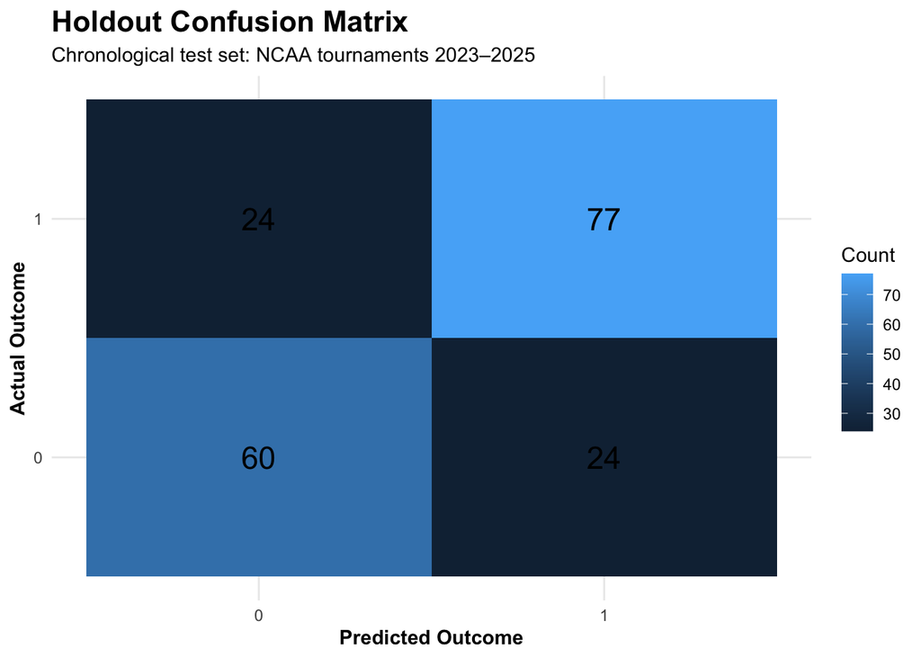

```r
# Create a tidy data frame from the confusion matrix
cm_df <- as.data.frame(confusion_matrix)

names(cm_df) <- c("Actual", "Predicted", "Count")

# Plot confusion matrix
library(ggplot2)

confusion_plot <- ggplot(
  cm_df,
  aes(x = Predicted, y = Actual, fill = Count)
) +
  geom_tile() +
  geom_text(
    aes(label = Count),
    size = 6
  ) +
  labs(
    title = "Holdout Confusion Matrix",
    subtitle = "Chronological test set: NCAA tournaments 2023–2025",
    x = "Predicted Outcome",
    y = "Actual Outcome"
  ) +
  theme_minimal() +
  theme(
    plot.title = element_text(face = "bold", size = 16),
    plot.subtitle = element_text(size = 11),
    axis.title = element_text(face = "bold")
  )

confusion_plot
```

```r
if (!dir.exists("figures")) {
  dir.create("figures", recursive = TRUE)
}

ggsave(
  filename = "figures/holdout_confusion_matrix.png",
  plot = confusion_plot,
  width = 7,
  height = 5,
  dpi = 300
)
```

## 12.2 Model Diagnostics

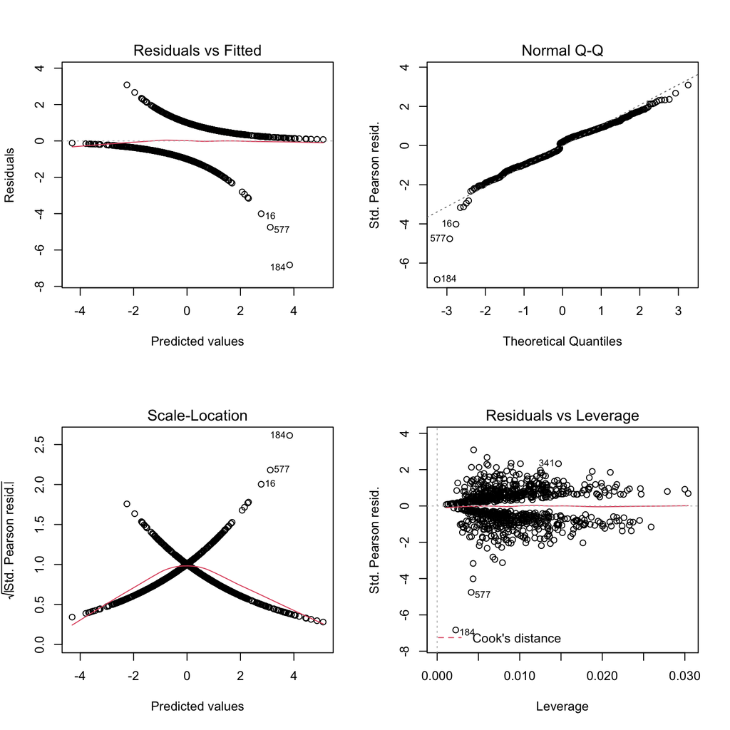

```r
par(mfrow = c(2, 2))

plot(final_model)
```

```r
par(mfrow = c(1, 1))
```

For logistic regression, residual normality is not a model requirement. Diagnostic plots are used primarily to identify unusual residual structure, influential observations, and potential model misspecification.

# 13 12. Supplied 2026 Matchup Probabilities

The supplied matchup file contains multiple 2026 placeholder rows across several tournament stages. This section generates probabilities for those supplied pairings without assuming that every listed future pairing will actually occur.

```r
prediction_2026$Team_A_Probability <- predict(
  final_model,
  newdata = prediction_2026,
  type = "response"
)
prediction_2026$Team_B_Probability <-
  1 - prediction_2026$Team_A_Probability

prediction_2026$Predicted_Winner <- ifelse(
  prediction_2026$Team_A_Probability >= 0.50,
  prediction_2026$Team_A,
  prediction_2026$Team_B
)

prediction_table <- prediction_2026 %>%
  select(
    YEAR,
    CURRENT_ROUND,
    Team_A,
    Team_B,
    Team_A_Probability,
    Team_B_Probability,
    Predicted_Winner
  ) %>%
  arrange(desc(CURRENT_ROUND))

head(prediction_table, 20)
```

```
## # A tibble: 20 × 7
##     YEAR CURRENT_ROUND Team_A       Team_B Team_A_Probability Team_B_Probability
##    <int>         <int> <chr>        <chr>               <dbl>              <dbl>
##  1  2026            64 Duke         Siena               0.988             0.0120
##  2  2026            64 Ohio St.     TCU                 0.642             0.358
##  3  2026            64 St. John's   North…              0.884             0.116
##  4  2026            64 Kansas       Cal B…              0.817             0.183
##  5  2026            64 Louisville   South…              0.744             0.256
##  6  2026            64 Michigan St. North…              0.870             0.130
##  7  2026            64 UCLA         UCF                 0.705             0.295
##  8  2026            64 Connecticut  Furman              0.979             0.0210
##  9  2026            64 Florida      Lehigh              0.989             0.0108
## 10  2026            64 Florida      Prair…              0.987             0.0130
## 11  2026            64 Clemson      Iowa                0.510             0.490
## 12  2026            64 Vanderbilt   McNee…              0.705             0.295
## 13  2026            64 Nebraska     Troy                0.941             0.0593
## 14  2026            64 North Carol… VCU                 0.667             0.333
## 15  2026            64 Illinois     Penn                0.952             0.0483
## 16  2026            64 Saint Mary's Texas…              0.623             0.377
## 17  2026            64 Houston      Idaho               0.986             0.0143
## 18  2026            64 Arizona      LIU B…              0.982             0.0184
## 19  2026            64 Villanova    Utah …              0.579             0.421
## 20  2026            64 Wisconsin    High …              0.798             0.202
## # ℹ 1 more variable: Predicted_Winner <chr>
```

## 13.1 2026 predictions

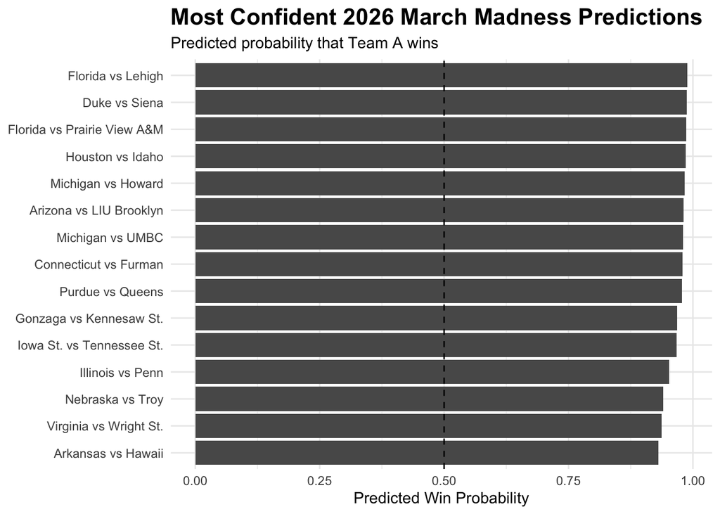

```r
# Take the most confident 2026 matchup predictions
top_2026_predictions <- prediction_2026 %>%
  mutate(
    Confidence = abs(Team_A_Probability - 0.50)
  ) %>%
  arrange(desc(Confidence)) %>%
  slice_head(n = 15) %>%
  mutate(
    Matchup = paste(Team_A, "vs", Team_B)
  )

prediction_plot <- ggplot(
  top_2026_predictions,
  aes(
    x = reorder(Matchup, Team_A_Probability),
    y = Team_A_Probability
  )
) +
  geom_col() +
  geom_hline(
    yintercept = 0.50,
    linetype = "dashed"
  ) +
  coord_flip() +
  labs(
    title = "Most Confident 2026 March Madness Predictions",
    subtitle = "Predicted probability that Team A wins",
    x = NULL,
    y = "Predicted Win Probability"
  ) +
  theme_minimal() +
  theme(
    plot.title = element_text(face = "bold", size = 16),
    plot.subtitle = element_text(size = 11)
  )

prediction_plot
```

```r
if (!dir.exists("figures")) {
  dir.create("figures", recursive = TRUE)
}

ggsave(
  filename = "figures/2026_predictions.png",
  plot = prediction_plot,
  width = 9,
  height = 7,
  dpi = 300
)
```

# 14 13. Kelly Criterion

The Kelly Criterion determines the bankroll fraction to wager when the model probability exceeds the break-even probability implied by the offered odds.

For decimal odds $d$:

$$b = d - 1$$

$$f^* = \frac{bp - (1-p)}{b}$$

where:

- $p$ = estimated probability of winning
- $b$ = net profit per dollar wagered
- $f^*$ = recommended fraction of bankroll

Negative Kelly fractions indicate that no wager should be placed.

```r
kelly_fraction <- function(probability, decimal_odds) {
  if (
    probability <= 0 ||
    probability >= 1 ||
    decimal_odds <= 1
  ) {
    stop("Probability must be between 0 and 1 and decimal odds must exceed 1.")
  }

  b <- decimal_odds - 1
  q <- 1 - probability

  raw_kelly <- (b * probability - q) / b

  max(0, raw_kelly)
}

# Example corresponding to approximately -400 American odds:
kelly_fraction(
  probability = 0.92,
  decimal_odds = 1.25
)
```

```
## [1] 0.6
```

A fractional Kelly strategy can reduce bankroll volatility:

```r
full_kelly <- kelly_fraction(
  probability = 0.92,
  decimal_odds = 1.25
)

half_kelly <- 0.5 * full_kelly

c(
  Full_Kelly = full_kelly,
  Half_Kelly = half_kelly
)
```

```
## Full_Kelly Half_Kelly
##        0.6        0.3
```

## 14.1 Optional Sportsbook Odds Integration

If a future file named `data/sportsbook_odds.csv` is added with matchup-specific sportsbook odds, it can be merged with the model probabilities and used to calculate actual betting recommendations.

A public GitHub version should distinguish clearly between:

- model-estimated win probabilities,
- sportsbook-implied probabilities,
- hypothetical/simulated odds, and
- historically observed sportsbook prices.

# 15 14. Limitations

This analysis has several important limitations:

1. The model relies on historical team-level performance metrics and does not explicitly include injuries, lineup changes, player availability, or game-specific context.
2. The current project folder does not contain a verified historical sportsbook-odds dataset, so real-world betting profitability cannot be validated from the available files alone.
3. The supplied 2026 file contains placeholder matchups across multiple stages; later-round predictions should not be interpreted as a fully simulated bracket unless bracket advancement logic is added.
4. Basketball metrics should ideally represent information available before each game. If any source metrics were calculated using games occurring after the prediction date, that would introduce look-ahead bias and should be addressed in a future version.

# 16 15. Conclusion

This project combines matchup-level feature engineering, regularized feature selection, multivariate statistics, logistic regression, and risk-based decision-making to estimate NCAA tournament win probabilities.

The next extension is to integrate verified historical betting odds and evaluate whether model-implied edges remain profitable after sportsbook vig and realistic bankroll constraints.